# STA_380N_PART2_EXAM

Mihir Deshpande

2022-08-04

# STA 280N Intro to Machine Learning Part 2 Take Home Exam

##### A link to a GitHub repo where the final report has been knitted and stored *in Markdown (.md) or PDF format*.

| Type | Link |
| --- | --- |
| RMD File | https://github.com/AmritangshuM/STA380-am222239-Amrit/blob/f2cd431d73536cf4fc606979a91c39ad18f26c2d/Final_Assignment_Amritangshu_mlV5.Rmd |

# ________________________________________________________

## Problem 1) Probability practice

**Part A.** Visitors to your website are asked to answer a single survey question before they get access to the content on the page. Among all of the users, there are two categories: Random Clicker (RC), and Truthful Clicker (TC). There are two possible answers to the survey: yes and no. Random clickers would click either one with equal probability. You are also giving the information that the expected fraction of random clickers is 0.3. After a trial period, you get the following survey results: 65% said Yes and 35% said No. What fraction of people who are truthful clickers answered yes? Hint: use the rule of total probability.

### Answer:

Let’s assume the total no. of people who answered survey = 100

$$S = 100$$

Now, we know expected fraction of Random Clickers (RC) = 0.3

$$P(RC) = 0.3$$

$$=> N(RC) = S*0.3 = 30$$
Now, Random Clickers are equally likely to answer Yes/No.

Therefore, of the 100 people who answered the survey, 30 were random clickers out of whom 15 answered **Yes** and 15 answered **No**

We know that at the end of the survey, we got 65% who voted Yes and 35% who voted No.

i.e

65 people voted **Yes** out of which 15 were Random Clickers => 50 who voted **Yes** were Truthful Clickers (TC)

35 people voted **No** out of which 15 were Random Clickers => 20 who voted **No** were Truthful Clickers (TC)

Therefore, Fraction of people who are Truthful Clickers (TC) who answered **Yes**

= 50/(50+20)

= **5/7**

**Part B.** Imagine a medical test for a disease with the following two attributes:

- The sensitivity is about 0.993. That is, if someone has the disease, there is a probability of 0.993 that they will test positive.
- The specificity is about 0.9999. This means that if someone doesn’t have the disease, there is probability of 0.9999 that they will test negative.
- In the general population, incidence of the disease is reasonably rare: about 0.0025% of all people have it (or 0.000025 as a decimal probability).

Suppose someone tests positive. What is the probability that they have the disease?

### Answer:

Let’s define the following events -

**P** = Event that you test Positive

**N** = Event that you test Negative

**D** = Event that you have the Disease

**ND** = Event that you don’t have the Disease

What is the probability that youi have the disease given you tested positive?

i.e

$$P(D \mid P) = ?$$

Now, we know the following -

$P(N \mid ND) = 0.9999$

$P(D) = 0.000025$

Now,

$P(ND) = 1-0.000025$

$\therefore P(ND) = 0.999975$

We know,
$$P(D \mid P) = \frac{P(D \cap
P)}{P(P)}$$

Let’s find the value of Numerator -

$P(P \mid D) = \frac {P(D \cap P)}{P(D)}$

$\therefore P(D \cap P) = P(P \mid D) \cdot P(D)$

Now,

$P(P) = \sum_{X=0}^{N} P(X \cap P)$

$P(P) = P(D \cap P) + P(ND \cap P)$

Now,

$P(P \mid ND) = 1 - P(N \mid ND)$

$\therefore P(P \mid ND) = 1 - 0.9999$

$\therefore P(P \mid ND) = 0.0001$

We know,

$P(P \mid ND) = \frac {P(ND \cap P)}{P(ND)}$

$\therefore P(ND \cap P) = P(P \mid ND) \cdot P(ND)$

$\therefore P(ND \cap P) = 0.0001*0.999975$

$\therefore P(ND \cap P) = 0.0000999975........(3)$

Now, from 2 and 3,

$P(P) = 0.0001233225........(4)$

From 1 and 4,

## Problem 2: Wrangling the Billboard Top 100

Consider the data in billboard.csv containing every song to appear on the weekly [Billboard Top 100](https://www.billboard.com/charts/hot-100/) chart since 1958, up through the middle of 2021. Each row of this data corresponds to a single song in a single week. For our purposes, the relevant columns here are:

- performer: who performed the song
- song: the title of the song
- year: year (1958 to 2021)
- week: chart week of that year (1, 2, etc)
- week_position: what position that song occupied that week on the Billboard top 100 chart.

Use your skills in data wrangling and plotting to answer the following three questions.

**Part A**: Make a table of the top 10 most popular songs since 1958, as measured by the *total number of weeks that a song spent on the Billboard Top 100.* Note that these data end in week 22 of 2021, so the most popular songs of 2021 will not have up-to-the-minute data; please send our apologies to The Weeknd.

### Solution:

Let’s group by song and performer, summarize and sort in descending order by week count and print the top 10 entries -

Table 2.1 Top 10 Songs and their artists with maximum number of weeks in Billboard 100

| song | performer | week_count |
| --- | --- | --- |
| Radioactive | Imagine Dragons | 87 |
| Sail | AWOLNATION | 79 |
| Blinding Lights | The Weeknd | 76 |
| I’m Yours | Jason Mraz | 76 |
| How Do I Live | LeAnn Rimes | 69 |
| Counting Stars | OneRepublic | 68 |
| Party Rock Anthem | LMFAO Featuring Lauren Bennett & GoonRock | 68 |
| Foolish Games/You Were Meant For Me | Jewel | 65 |
| Rolling In The Deep | Adele | 65 |
| Before He Cheats | Carrie Underwood | 64 |

**Part B**: Is the “musical diversity” of the Billboard Top 100 changing over time? Let’s find out. We’ll measure the musical diversity of given year as *the number of unique songs that appeared in the Billboard Top 100 that year.* Make a line graph that plots this measure of musical diversity over the years. The x axis should show the year, while the y axis should show the number of unique songs appearing at any position on the Billboard Top 100 chart in any week that year. For this part, please filter the data set so that it excludes the years 1958 and 2021, since we do not have complete data on either of those years. Give the figure an informative caption in which you explain what is shown in the figure and comment on any interesting trends you see.

There are number of ways to accomplish the data wrangling here. We offer you two hints on two possibilities:

1. You could use two distinct sets of data-wrangling steps. The first set of steps would get you a table that counts the number of times that a given song appears on the Top 100 in a given year. The second set of steps operate on the result of the first set of steps; it would count the number of unique songs that appeared on the Top 100 in each year, *irrespective of how many times* it had appeared.
2. You could use a single set of data-wrangling steps that combines the `length` and `unique` commands.

### Solution:

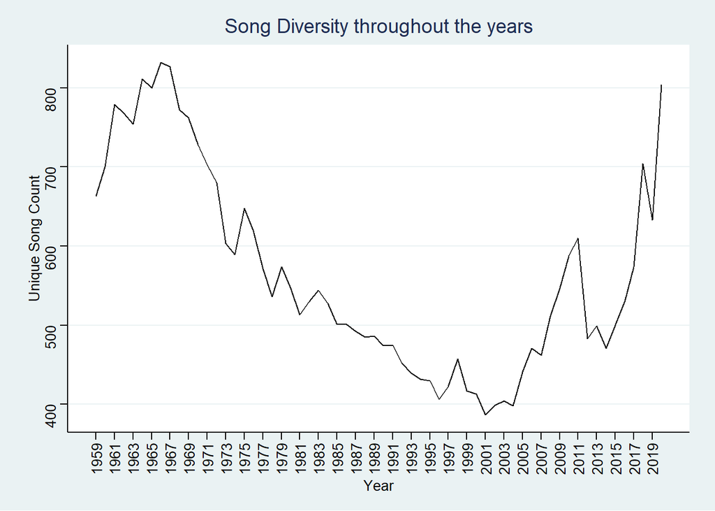

We can see that from the mid 1980s to the mid 2000s, we don’t really have a lot of song diversity! The unique no. of songs that top the **Billboard 100** significantly drop in this era but we are seeing a rise in diversity from 2007 onwards.

**Part C**: Let’s define a “ten-week hit” as a single song that appeared on the Billboard Top 100 for at least ten weeks. There are 19 artists in U.S. musical history since 1958 who have had *at least 30 songs* that were “ten-week hits.” Make a bar plot for these 19 artists, showing how many ten-week hits each one had in their musical career. Give the plot an informative caption in which you explain what is shown.

### Solution:

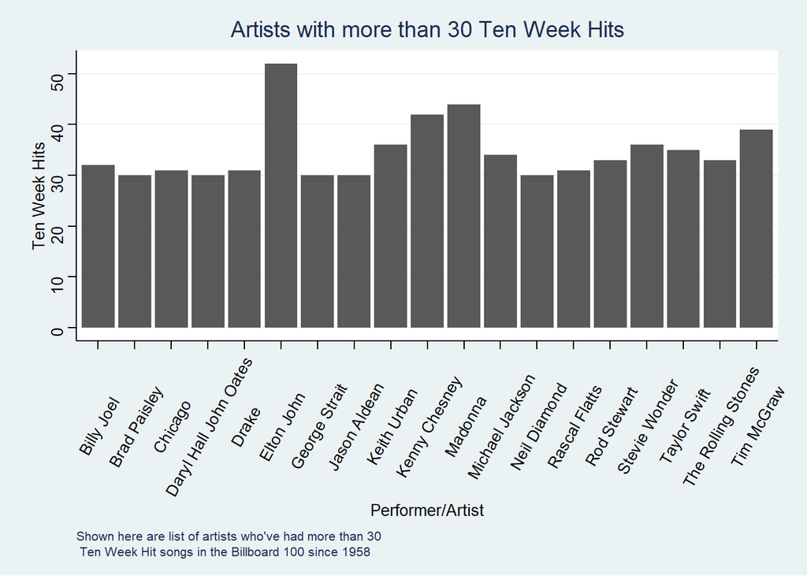

## Visual story telling part 1: green buildings

### The case

Over the past decade, both investors and the general public have paid increasingly close attention to the benefits of environmentally conscious buildings. There are both ethical and economic forces at work here. In commercial real estate, issues of eco-friendliness are intimately tied up with ordinary decisions about how to allocate capital. In this context, the decision to invest in eco-friendly buildings could pay off in at least four ways.

1. Every building has the obvious list of recurring costs: water, climate control, lighting, waste disposal, and so forth. Almost by definition, these costs are lower in green buildings.
2. Green buildings are often associated with better indoor environments—the kind that are full of sunlight, natural materials, and various other humane touches. Such environments, in turn, might result in higher employee productivity and lower absenteeism, and might therefore be more coveted by potential tenants. The financial impact of this factor, however, is rather hard to quantify ex ante; you cannot simply ask an engineer in the same way that you could ask a question such as, “How much are these solar panels likely to save on the power bill?”
3. Green buildings make for good PR. They send a signal about social responsibility and ecological awareness, and might therefore command a premium from potential tenants who want their customers to associate them with these values. It is widely believed that a good corporate image may enable a firm to charge premium prices, to hire better talent, and to attract socially conscious investors.
4. Finally, sustainable buildings might have longer economically valuable lives. For one thing, they are expected to last longer, in a direct physical sense. (One of the core concepts of the green-building movement is “life-cycle analysis,” which accounts for the high front-end environmental impact of ac- quiring materials and constructing a new building in the first place.) Moreover, green buildings may also be less susceptible to market risk—in particular, the risk that energy prices will spike, driving away tenants into the arms of bolder, greener investors.

Of course, much of this is mere conjecture. At the end of the day, tenants may or may not be willing to pay a premium for rental space in green buildings. We can only find out by carefully examining data on the commercial real-estate market.

The file greenbuildings.csv contains data on 7,894 commercial rental properties from across the United States. Of these, 685 properties have been awarded either LEED or EnergyStar certification as a green building. You can easily find out more about these rating systems on the web, e.g. at www.usgbc.org. The basic idea is that a commercial property can receive a green certification if its energy efficiency, carbon footprint, site selection, and building materials meet certain environmental benchmarks, as certified by outside engineers.

A group of real estate economists constructed the data in the following way. Of the 1,360 green-certified buildings listed as of December 2007 on the LEED or EnergyStar websites, current information about building characteristics and monthly rents were available for 685 of them. In order to provide a control population, each of these 685 buildings was matched to a cluster of nearby commercial buildings in the CoStar database. Each small cluster contains one green-certified building, and all non-rated buildings within a quarter-mile radius of the certified building. On average, each of the 685 clusters contains roughly 12 buildings, for a total of 7,894 data points.

The columns of the data set are coded as follows:

- CS.PropertyID: the building’s unique identifier in the CoStar database.
- cluster: an identifier for the building cluster, with each cluster containing one green-certified building and at least one other non-green-certified building within a quarter-mile radius of the cluster center.
- size: the total square footage of available rental space in the building.
- empl.gr: the year-on-year growth rate in employment in the building’s geographic region.
- Rent: the rent charged to tenants in the building, in dollars per square foot per calendar year.
- leasing.rate: a measure of occupancy; the fraction of the building’s available space currently under lease.
- stories: the height of the building in stories.
- age: the age of the building in years.
- renovated: whether the building has undergone substantial renovations during its lifetime.
- class.a, class.b: indicators for two classes of building quality (the third is Class C). These are relative classifications within a specific market. Class A buildings are generally the highest-quality properties in a given market. Class B buildings are a notch down, but still of reasonable quality. Class C buildings are the least desirable properties in a given market.
- green.rating: an indicator for whether the building is either LEED- or EnergyStar-certified.
- LEED, Energystar: indicators for the two specific kinds of green certifications.
- net: an indicator as to whether the rent is quoted on a “net contract” basis. Tenants with net-rental contracts pay their own utility costs, which are otherwise included in the quoted rental price.
- amenities: an indicator of whether at least one of the following amenities is available on-site: bank, convenience store, dry cleaner, restaurant, retail shops, fitness center.
- cd.total.07: number of cooling degree days in the building’s region in 2007. A degree day is a measure of demand for energy; higher values mean greater demand. Cooling degree days are measured relative to a baseline outdoor temperature, below which a building needs no cooling.
- hd.total07: number of heating degree days in the building’s region in 2007. Heating degree days are also measured relative to a baseline outdoor temperature, above which a building needs no heating.
- total.dd.07: the total number of degree days (either heating or cooling) in the building’s region in 2007.
- Precipitation: annual precipitation in inches in the building’s geographic region.
- Gas.Costs: a measure of how much natural gas costs in the building’s geographic region.
- Electricity.Costs: a measure of how much electricity costs in the building’s geographic region.
- cluster.rent: a measure of average rent per square-foot per calendar year in the building’s local market.

### The goal

An Austin real-estate developer is interested in the possible economic impact of “going green” in her latest project: a new 15-story mixed-use building on East Cesar Chavez, just across I-35 from downtown. Will investing in a green building be worth it, from an economic perspective? The baseline construction costs are $100 million, with a 5% expected premium for green certification.

The developer has had someone on her staff, who’s been described to her as a “total Excel guru from his undergrad statistics course,” run some numbers on this data set and make a preliminary recommendation. Here’s how this person described his process.

> I began by cleaning the data a little bit. In particular, I noticed that a handful of the buildings in the data set had very low occupancy rates (less than 10% of available space occupied). I decided to remove these buildings from consideration, on the theory that these buildings might have something weird going on with them, and could potentially distort the analysis. Once I scrubbed these low-occupancy buildings from the data set, I looked at the green buildings and non-green buildings separately. The median market rent in the non-green buildings was $25 per square foot per year, while the median market rent in the green buildings was $27.60 per square foot per year: about $2.60 more per square foot. (I used the median rather than the mean, because there were still some outliers in the data, and the median is a lot more robust to outliers.) Because our building would be 250,000 square feet, this would translate into an additional $250000 x 2.6 = $650000 of extra revenue per year if we build the green building.

> Our expected baseline construction costs are $100 million, with a 5% expected premium for green certification. Thus we should expect to spend an extra $5 million on the green building. Based on the extra revenue we would make, we would recuperate these costs in $5000000/650000 = 7.7 years. Even if our occupancy rate were only 90%, we would still recuperate the costs in a little over 8 years. Thus from year 9 onwards, we would be making an extra $650,000 per year in profit. Since the building will be earning rents for 30 years or more, it seems like a good financial move to build the green building.

The developer listened to this recommendation, understood the analysis, and still felt unconvinced. She has therefore asked you to revisit the report, so that she can get a second opinion.

Do you agree with the conclusions of her on-staff stats guru? If so, point to evidence supporting his case. If not, explain specifically where and why the analysis goes wrong, and how it can be improved. Do you see the possibility of confounding variables for the relationship between rent and green status? If so, provide evidence for confounding, and see if you can also make a picture that visually shows how we might “adjust” for such a confounder. *Tell your story in pictures, with appropriate introductory and supporting text.*

Note: this is intended as an exercise in visual and numerical story-telling. Your approach should rely on pictures and/or tables, not a regression model. Tell a story understandable to a non-technical audience. Keep it concise.

### Solution:

```
## [1] "Lets check if we have any missing values"
```

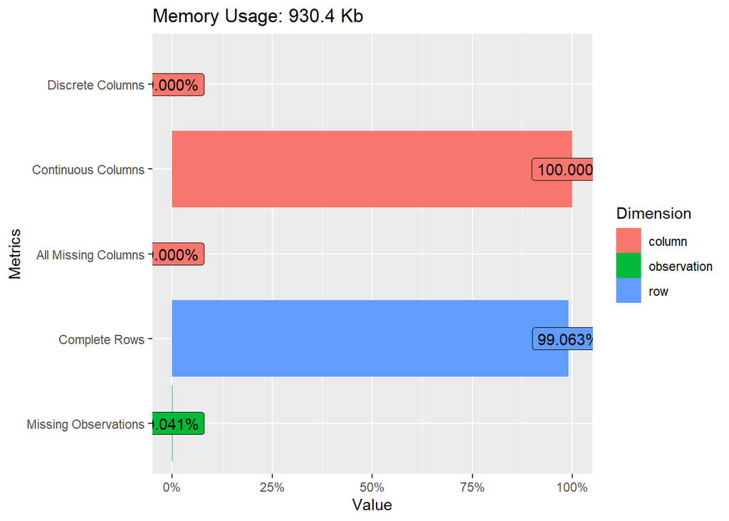

```
## [1] "Lets look at the distribution of the data"
```

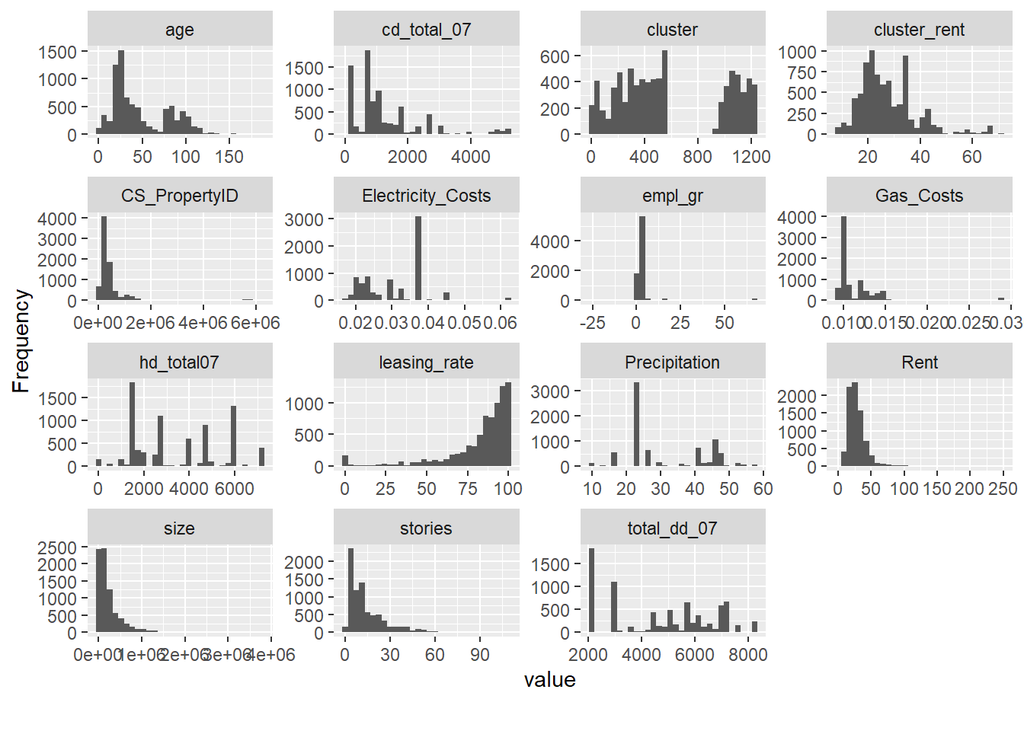

```
## [1] "Lets look at the correltion between these variables"
```

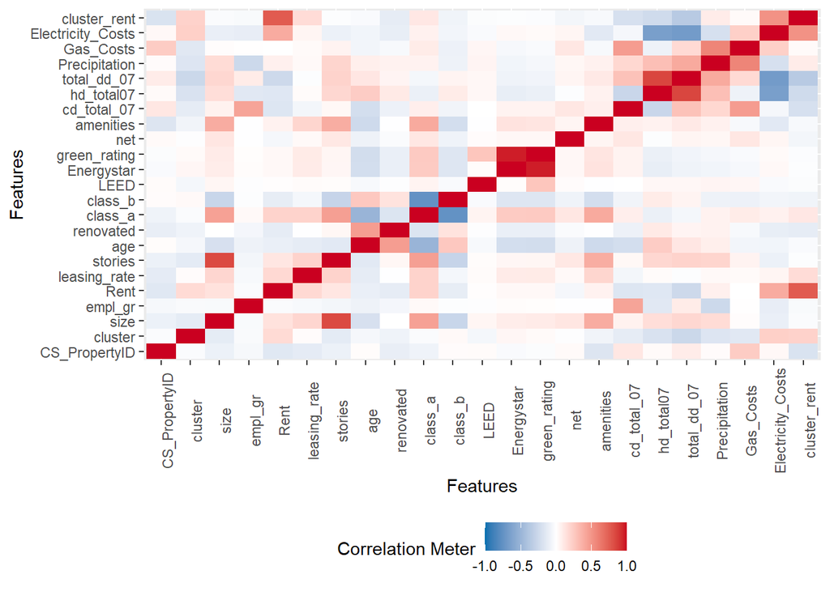

```
## [1] "Lets look at the pairwise correltion between these variables"
```

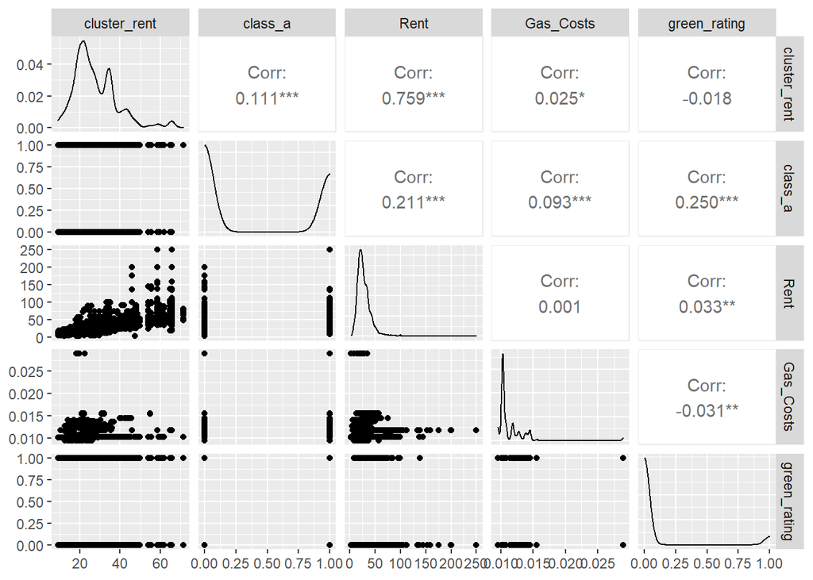

```
## [1] "Lets look at the mean and median rent in the data"
```

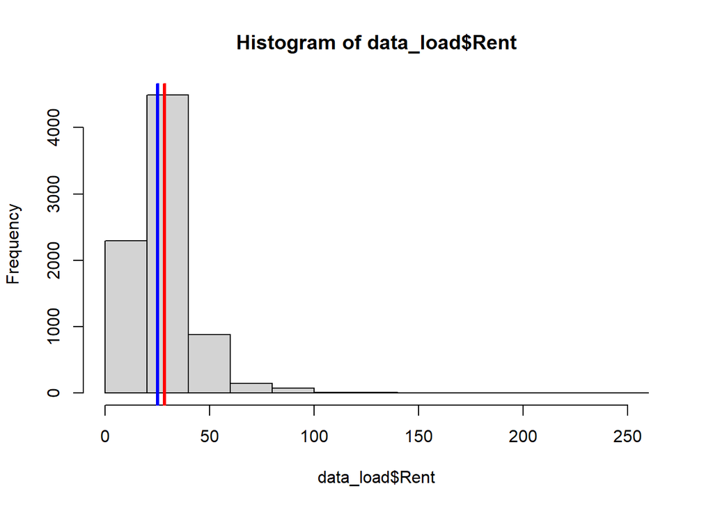

```
## [1] "Lets look at the distribution of these features across various metrics"
```

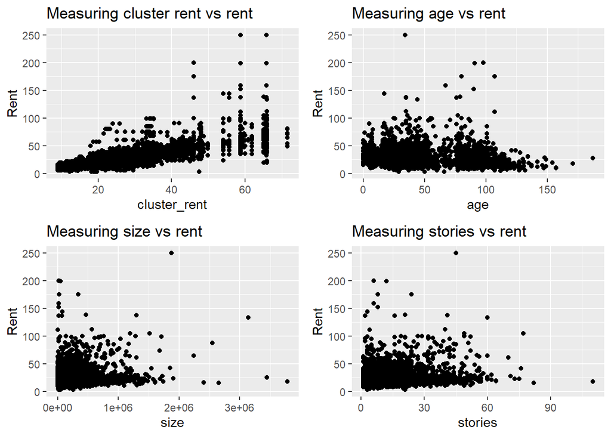

```
## [1] "we observed that Rent is correlated with the cluster rent, size, class A. Additionally, Class a buildings get higher rent"
```

```
## [1] "Lets look at the impact of Class A buildings on rent of green rated houses"
```

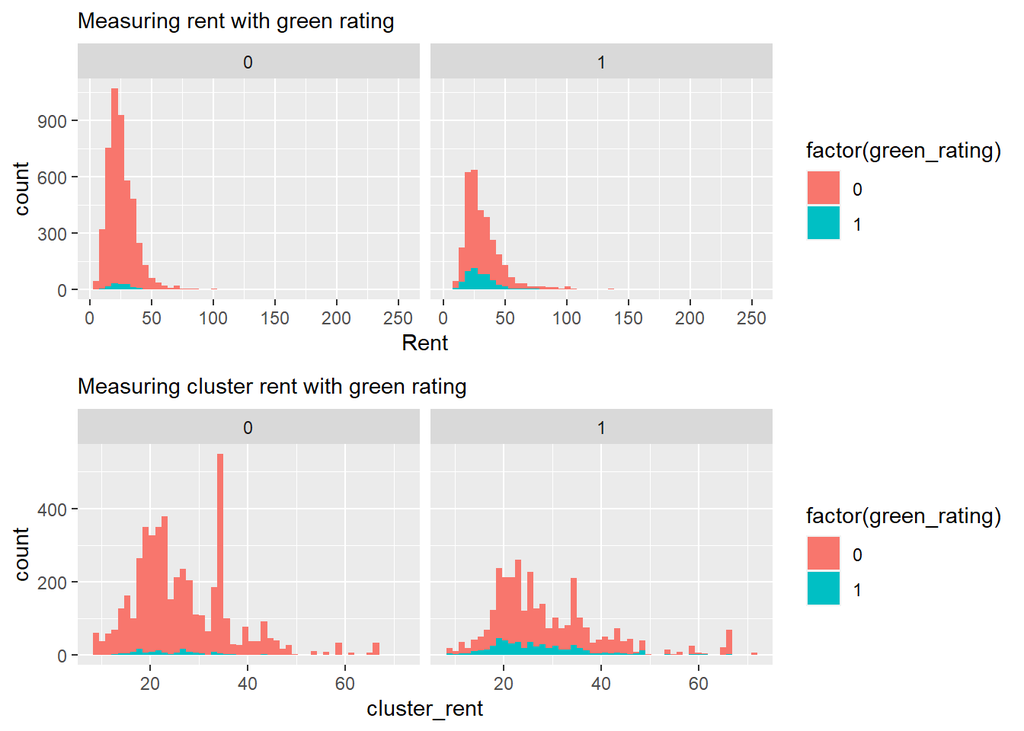

```
## [1] "we can observe that the class A buildings have better rent if they are green rated here"
```

```
## [1] "Lets look at the consumption of resources for green buildings"
```

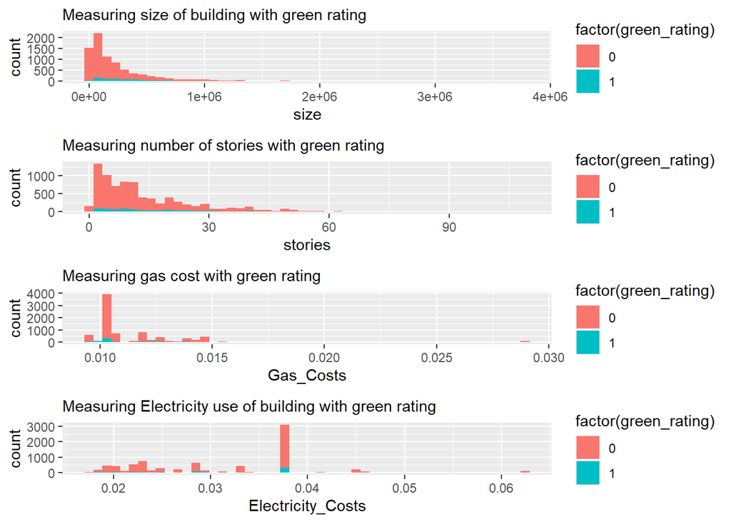

```
## [1] "Lets look at the density of green rated houses with various metrics"
```

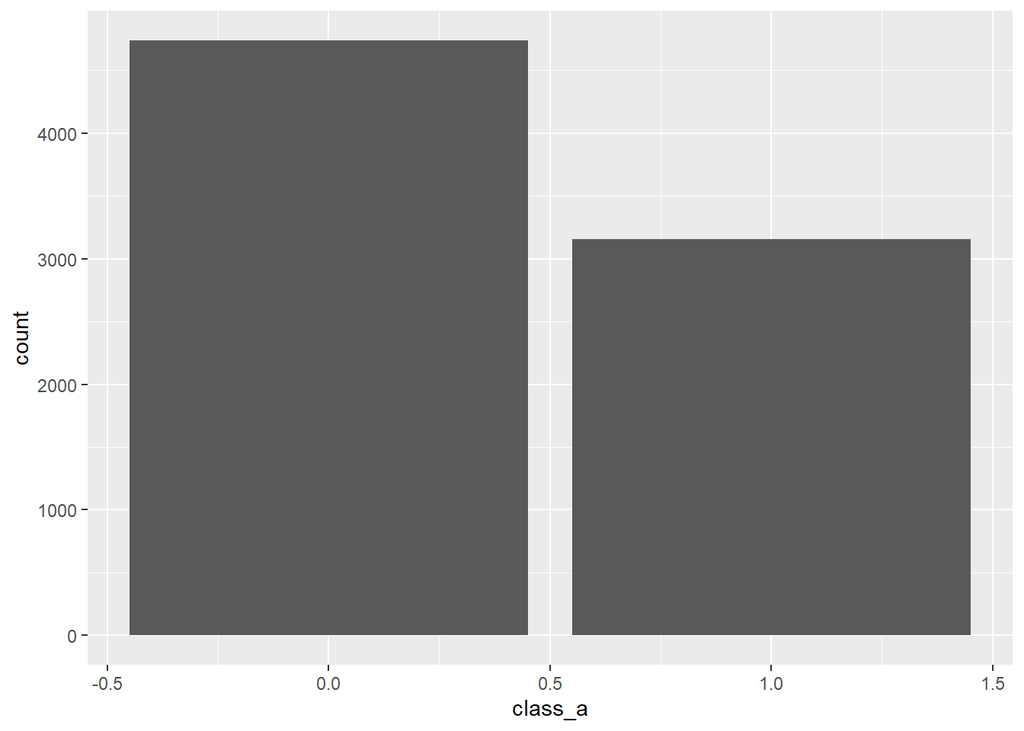

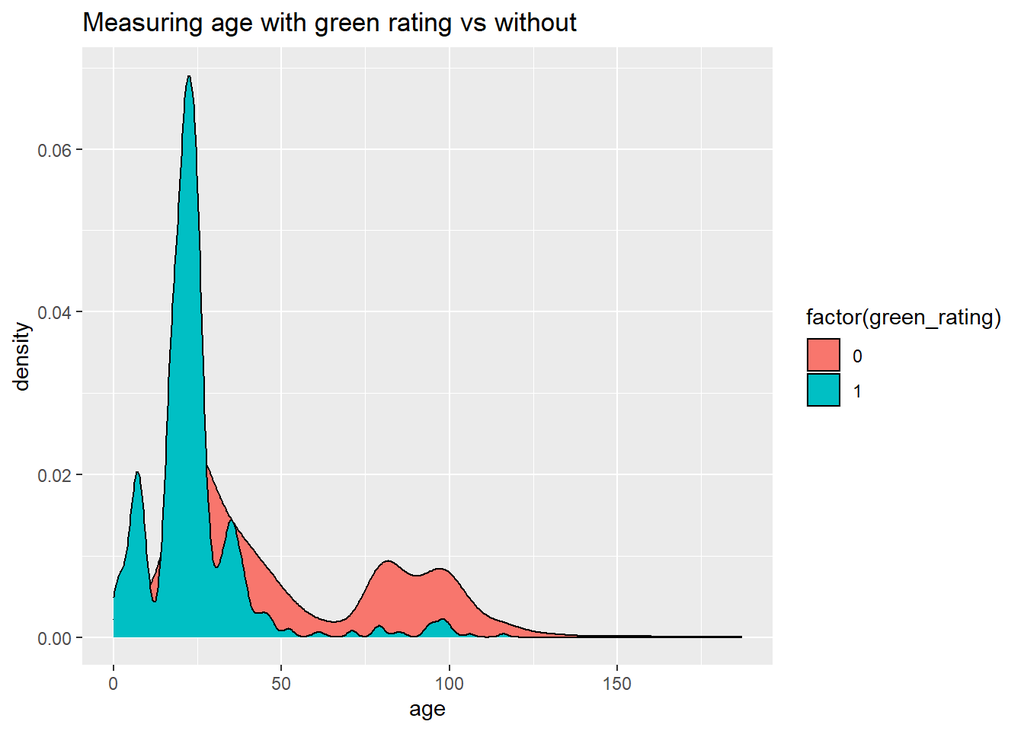

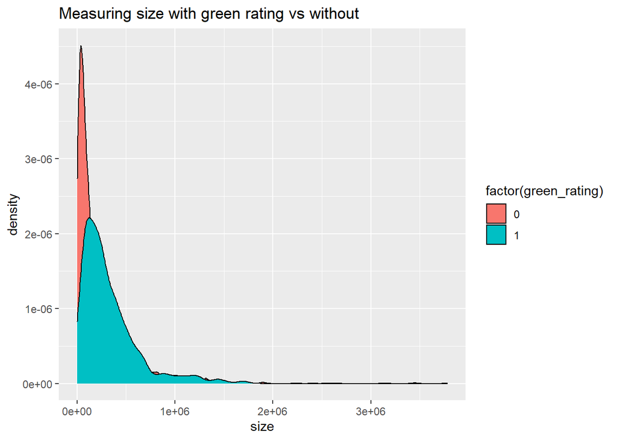

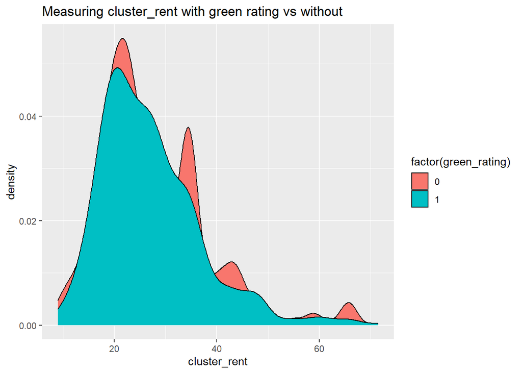

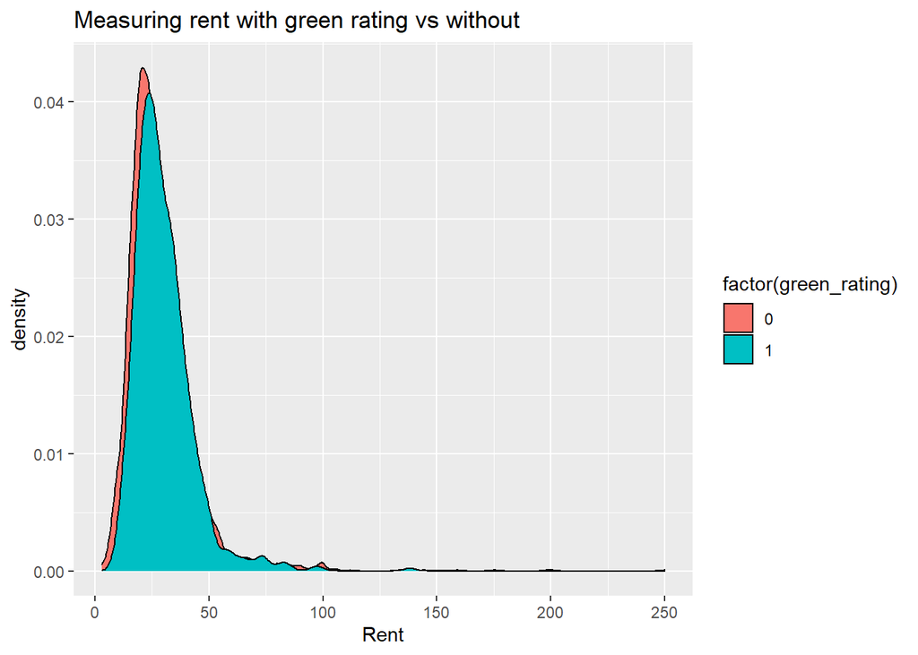

We observed most of the green buildings are younger than non-green buildings and the proportion of class a buildings is higher in green buildings

Since Stats Guru fails to account for all factors that affect rent, his analysis is wrong In order to calculate the returns, he began by using the median rent for all buildings.Because of this, he fails to factor in other factors, such as the size and class of the buildings,into his analysis. For instance, we have a class A building will yield a higher rent than a non-green building.

## Visual story telling part 2: Capital Metro data

The file capmetro_UT.csv contains data from Austin’s own Capital Metro bus network, including shuttles to, from, and around the UT campus. These data track ridership on buses in the UT area. Ridership is measured by an optical scanner that counts how many people embark and alight the bus at each stop. Each row in the data set corresponds to a 15-minute period between the hours of 6 AM and 10 PM, each and every day, from September through November 2018. The variables are:

- *timestamp*: the beginning of the 15-minute window for that row of data
- *boarding*: how many people got on board any Capital Metro bus on the UT campus in the specific 15 minute window
- *alighting*: how many people got off (“alit”) any Capital Metro bus on the UT campus in the specific 15 minute window
- *day_of_week* and *weekend*: Monday, Tuesday, etc, as well as an indicator for whether it’s a weekend.
- *temperature*: temperature at that time in degrees F
- *hour_of_day*: on 24-hour time, so 6 for 6 AM, 13 for 1 PM, 14 for 2 PM, etc.
- *month*: July through December

Your task is to create a figure, or set of related figures, that tell an interesting story about Capital Metro ridership patterns around the UT-Austin campus during the semester in question. Provide a clear annotation/caption for each figure, but the figure(s) should be more or less stand-alone, in that you shouldn’t need many, many paragraphs to convey its meaning. Rather, the figure together with a concise caption should speak for itself as far as possible.

You have broad freedom to look at any variables you’d like here – try to find that sweet spot where you’re showing genuinely interesting relationships among more than just two variables, but where the resulting figure or set of figures doesn’t become overwhelming/confusing. (Faceting/panel plots might be especially useful here.)

### Solution:

To figure out interesting Capital Metro ridership patterns around the UT-Austin we started with loading the data and then looking at various aspects of the same. We focused on weekly, monthly ridership and also the riding trends during the day.

```
## [1] "Lets check if we have any missing values"
```

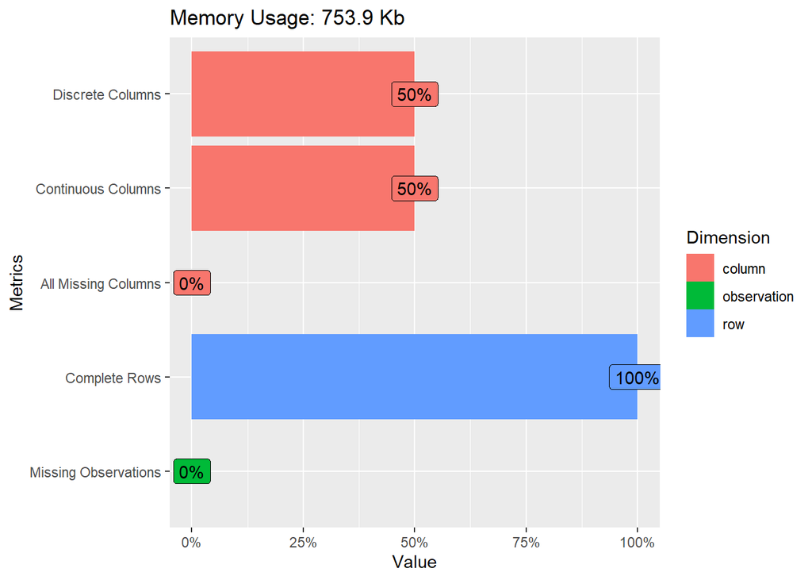

```
## [1] "We can now plot the distribution of this data"
```

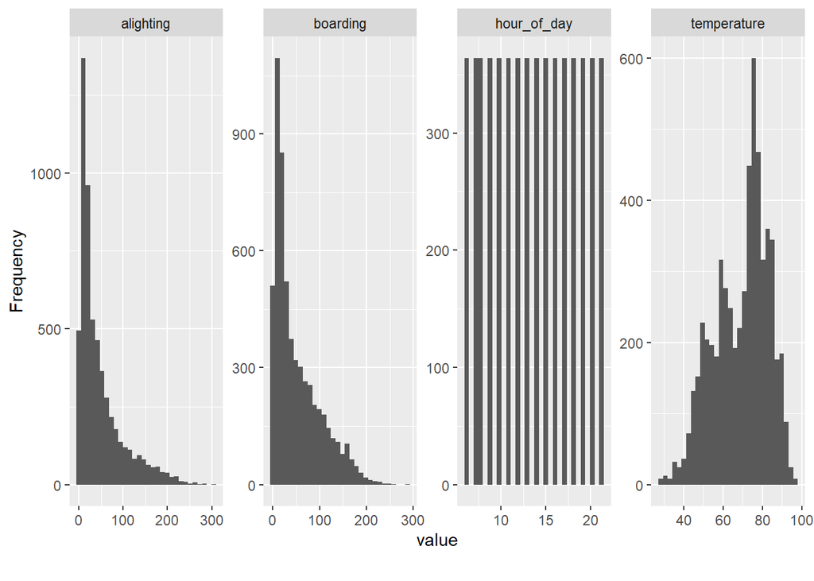

```
## [1] "lets look at the hourly trend of ridership"
```

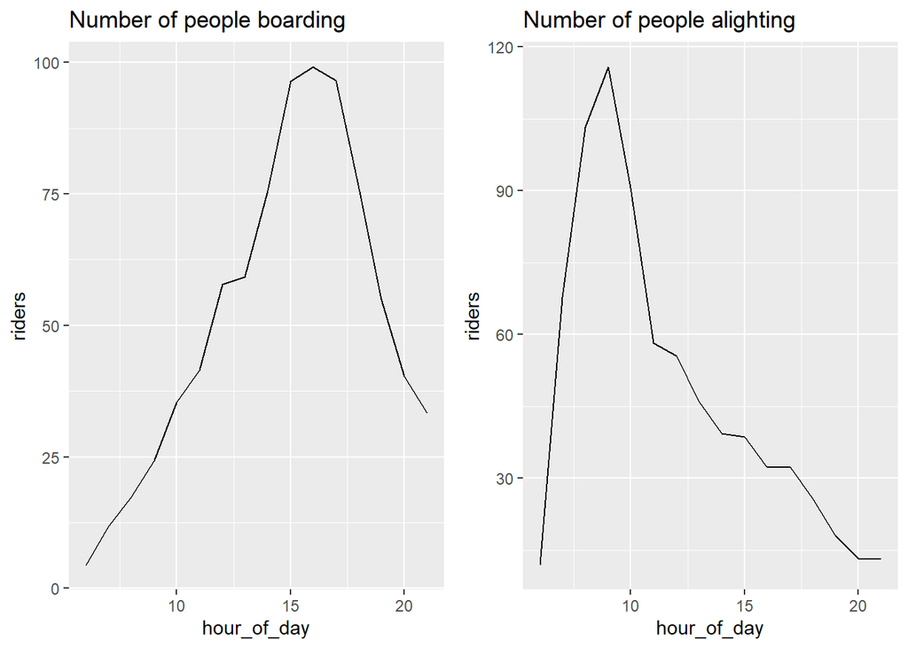

```
## [1] "Lets look at the weekly trend of ridership"
```

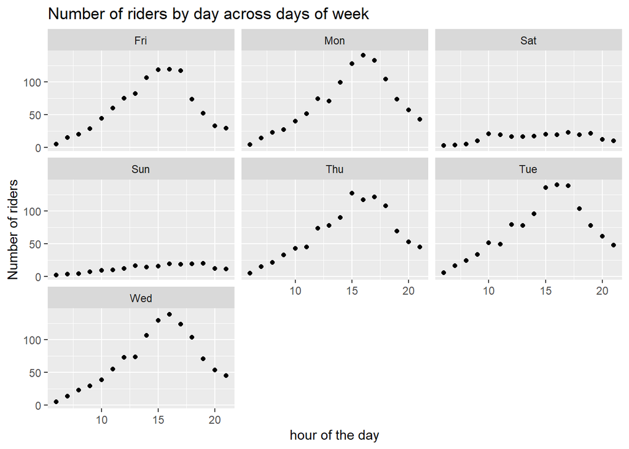

```
## [1] "lets look at the monthly trend of ridership"
```

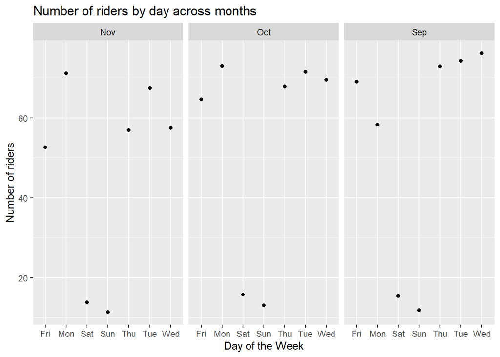

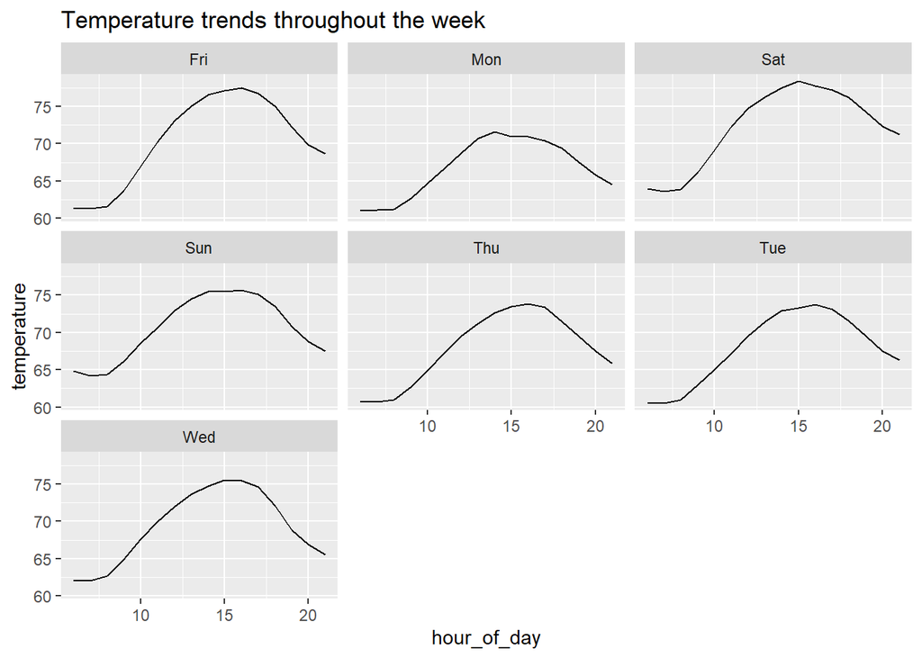

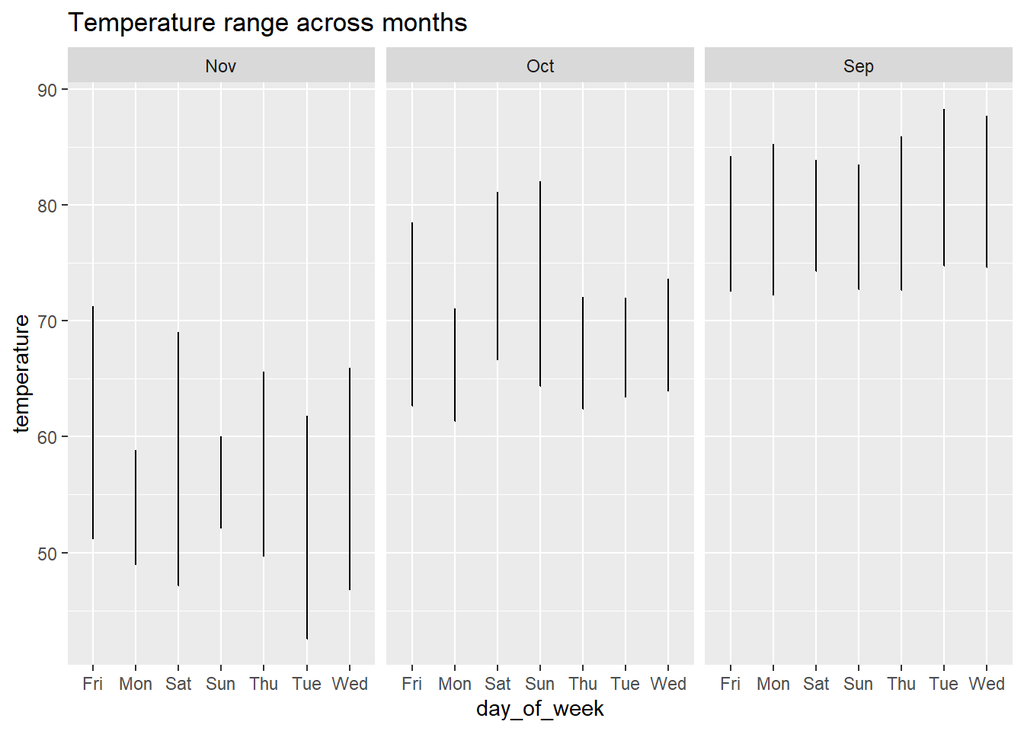

We looked at the daily, weekly and monthly distributions of the data and saw interesting trends like more people leave the bus during the early part of the day and interestingly the temperature of day can also be measure from this data. We also looked at monthly trends in ridership across the months of Oct, Sep and Nov. We also looked at temperature trends and ridership throughout the week.

```
##   timestamp            boarding        alighting      day_of_week
##  Length:5824        Min.   :  0.00   Min.   :  0.00   Length:5824
##  Class :character   1st Qu.: 13.00   1st Qu.: 13.00   Class :character
##  Mode  :character   Median : 33.00   Median : 28.00   Mode  :character
##                     Mean   : 51.51   Mean   : 47.65
##                     3rd Qu.: 79.25   3rd Qu.: 64.00
##                     Max.   :288.00   Max.   :304.00
##   temperature     hour_of_day       month             weekend
##  Min.   :29.18   Min.   : 6.00   Length:5824        Length:5824
##  1st Qu.:59.20   1st Qu.: 9.75   Class :character   Class :character
##  Median :72.75   Median :13.50   Mode  :character   Mode  :character
##  Mean   :69.28   Mean   :13.50
##  3rd Qu.:79.29   3rd Qu.:17.25
##  Max.   :97.64   Max.   :21.00
```

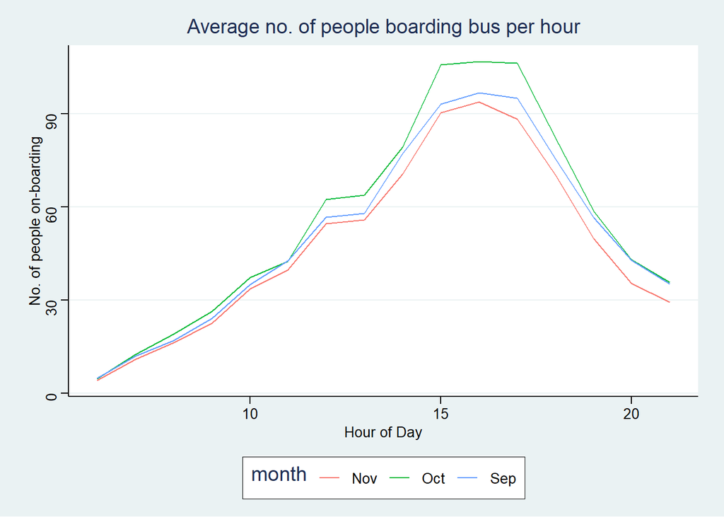

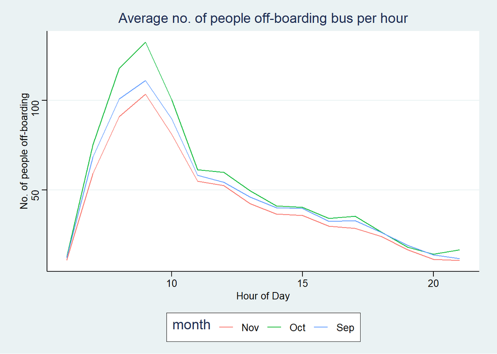

There are some weird discrepancies if you look at it without thinking much.

This distribution seems to be heavily influenced by students going to and fro from campus for college. Let’s try to look at the distribution on the weekends -

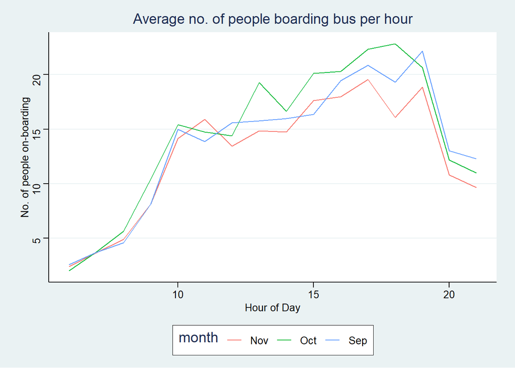

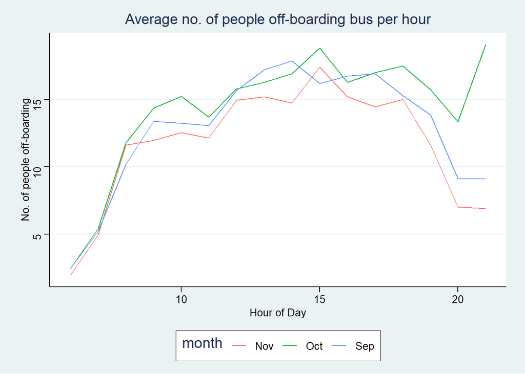

- The counts are much more varying throughout the day now
- There is an interesting spike in no. of off-boarding people in October towards the end of the day. Maybe this is because October is when students have their mid-terms for the semester so they tend to stay late on campus and go home during late hours of the day.

Let’s also look at how weekend ridership changes based on temperature (since the weekday ridership is expected to not be affected by temperature since students have to go to college regardless) -

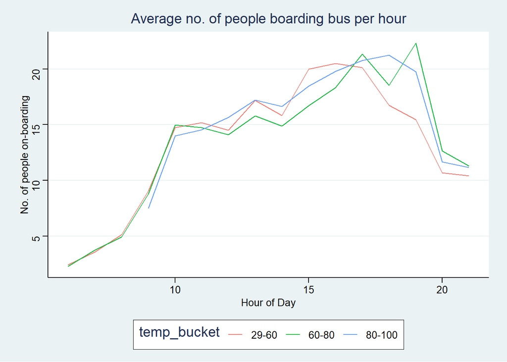

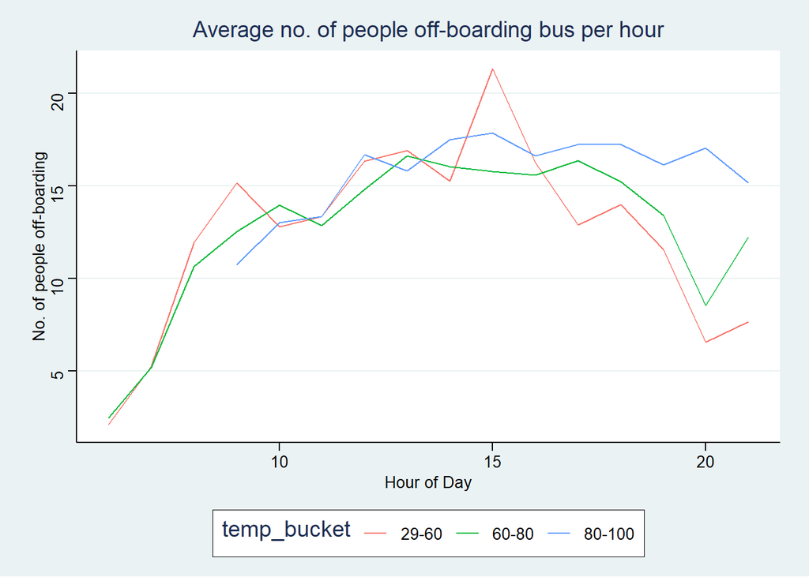

- The temperature doesn’t seem to affect ridership during the weekend so much since the patterns and numbers match those when we don’t account for temperature separately. We’ve got some pretty interesting insights from these graphs!

Finally, let’s look at the difference in total on-boardings and off-boardings per day -

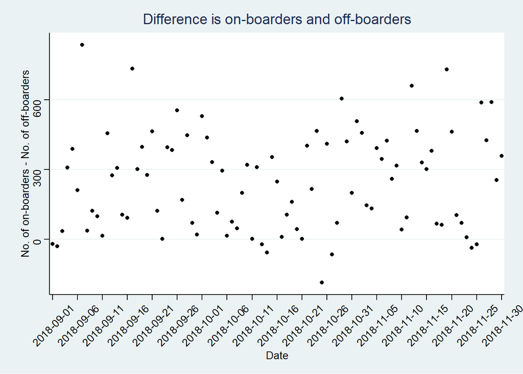

## Portfolio modeling

### Background

In this problem, you will construct three different portfolios of exchange-traded funds, or ETFs, and use bootstrap resampling to analyze the short-term tail risk of your portfolios. If you’re unfamiliar with exchange-traded funds, you can read a bit about them [here](http://www.investopedia.com/terms/e/etf.asp).

### The goal

Suppose you have $100,000 in capital. Your task is to:  
- Construct two different possibilities for an ETF-based portfolio, each involving an allocation of your $100,000 in capital to somewhere between 3 and 10 different ETFs. You can find a [big database of ETFs here.](https://etfdb.com/etfdb-categories/)  
- Download the last five years of daily data on your chosen ETFs, using the functions in the `quantmod` package, as we used in class. Note: make sure to choose ETFs for which at least five years of data are available. There are tons of ETFs and some are quite new!  
- Use bootstrap resampling to estimate the 4-week (20 trading day) value at risk of each of your three portfolios at the 5% level.  
- Write a report summarizing your portfolios and your VaR findings.

You should assume that your portfolios are rebalanced each day at zero transaction cost. For example, if you’re allocating your wealth evenly among 5 ETFs, you always redistribute your wealth at the end of each day so that the equal five-way split is retained, regardless of that day’s appreciation/depreciation.

Notes: - Make sure the portfolios are different from each other! (Maybe one seems safe, another aggressive, or something like that.) You’re not being graded on what specific portfolios you choose… just provide some context for your choices.

### Solution:

Let’s create a 5-ETF portfolio with 3 ETFs from the Oil sector and hedge them with 2 Green Energy ETFs. How would such a portfolio perform throughout the past 5 years?

Let’s construct it out of the following ETFs-

1. BNO: United States Brent Oil Fund LP
2. IEO: iShares US Oil & Gas Exploration & Production ETF
3. IEZ: iShares U.S. Oil Equipment & Services ETF
4. ICLN: iShares Global Clean Energy ETF
5. TAN: Invesco Solar ETF

Let’s assign $20,000 to each ETF and look at what our 4 week return distribution looks like when bootstrapped for 5000 iterations -

```
## [1] "BNO"  "IEO"  "TAN"  "IEZ"  "ICLN"
```

```
##               ClCl.BNOa     ClCl.IEOa    ClCl.IEZa    ClCl.TANa   ClCl.ICLNa
## 2017-08-08           NA            NA           NA           NA           NA
## 2017-08-09  0.013818182 -0.0011148644 -0.010286845 -0.006369427 -0.008743169
## 2017-08-10 -0.018651363 -0.0167410162 -0.018267717 -0.027472527 -0.013230430
## 2017-08-11  0.005847953  0.0007567348 -0.003849888  0.010828578  0.001117318
## 2017-08-14 -0.026889535 -0.0085066348 -0.003542609  0.011644155  0.008928571
## 2017-08-15  0.004480956 -0.0041944899 -0.013897899  0.009668555  0.002212389
```

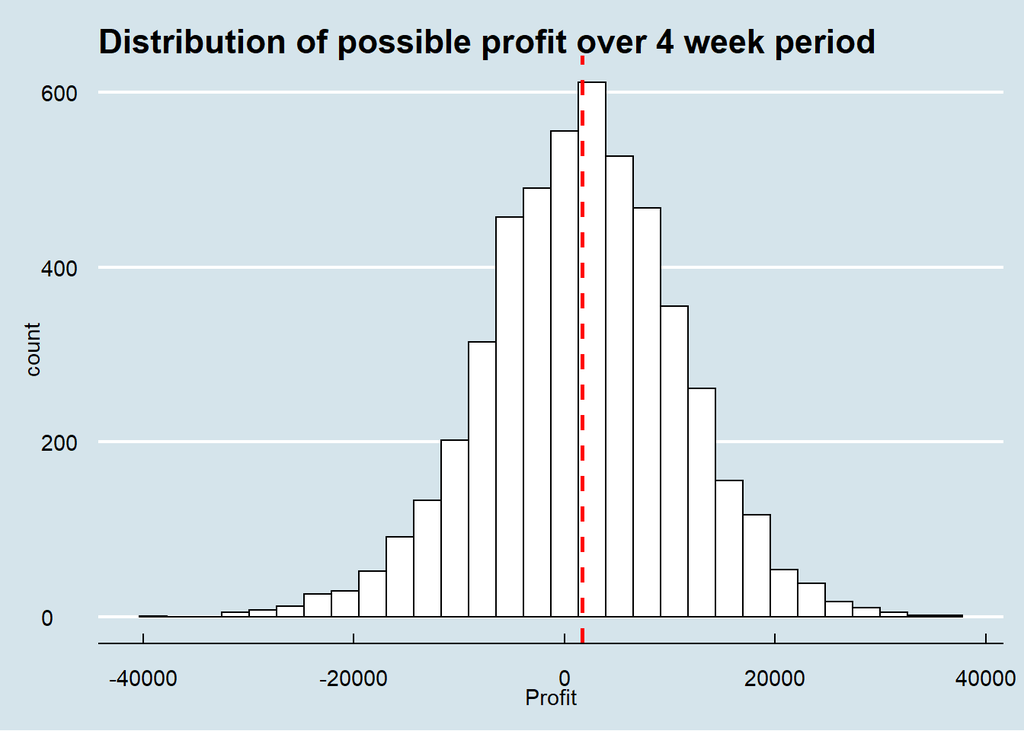

What’s our Value at Risk for this portfolio for a 4 week period with a 5% confidence?

```
##        5%
## -13604.51
```

Quick side note - What if we take data from the past 2 years for this portfolio and check? (given that most of these clean energy ETFs started to pick up the pace from Mid 2020)

Let’s look at the profit distributions -

```
## [1] "BNO"  "IEO"  "TAN"  "IEZ"  "ICLN"
```

```
##               ClCl.BNOa    ClCl.IEOa    ClCl.IEZa   ClCl.TANa   ClCl.ICLNa
## 2020-08-10           NA           NA           NA          NA           NA
## 2020-08-11 -0.011996572 -0.014133200  0.009980040 -0.03120123 -0.016311167
## 2020-08-12  0.019080659  0.016968929  0.008893281  0.02878424  0.017219388
## 2020-08-13 -0.004255319 -0.022727188 -0.020568071  0.02543532  0.016927837
## 2020-08-14 -0.005128205  0.017368266  0.008000000 -0.01621826 -0.007398213
## 2020-08-17  0.009450172 -0.006944473 -0.012896825  0.01532190  0.011801304
```

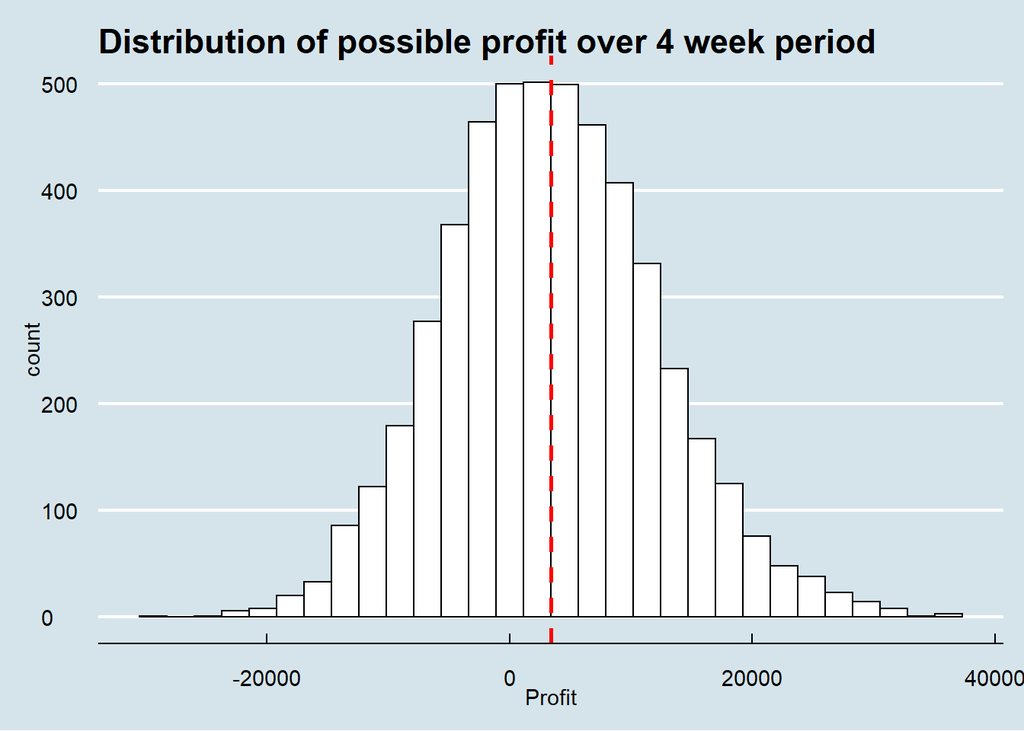

What’s our Value at Risk for this portfolio for a 4 week period with a 5% confidence?

```
##       5%
## -10511.4
```

Okay, sidebar over.

Let’s construct another portfolio but a bit more diversified this time-

1. XLF: Financial Select Sector SPDR Fund
2. IYH: iShares U.S. Healthcare ETF
3. XLY: Consumer Discretionary Select Sector SPDR Fund
4. QQQ: Invesco QQQ Trust
5. XLK: Technology Select Sector SPDR Fund
6. XLE: Energy Select Sector SPDR Fund
7. FXZ: First Trust Materials AlphaDEX Fund
8. FLOT: iShares Floating Rate Bond ETF
9. BKLN: Invesco Senior Loan ETF
10. VMBS: Vanguard Mortgage-Backed Securities ETF

```
##  [1] "XLF"  "IYH"  "XLY"  "QQQ"  "XLK"  "XLE"  "FXZ"  "FLOT" "BKLN" "VMBS"
```

```
##                ClCl.XLFa     ClCl.IYHa    ClCl.XLYa     ClCl.QQQa     ClCl.XLKa
## 2017-08-08            NA            NA           NA            NA            NA
## 2017-08-09  0.0000000000  0.0017454590 -0.005805663 -0.0013166309 -0.0005183656
## 2017-08-10 -0.0178006718 -0.0138788571 -0.014984574 -0.0214404393 -0.0197061200
## 2017-08-11 -0.0040273862  0.0035337963  0.005145403  0.0075870879  0.0068770765
## 2017-08-14  0.0137484836  0.0063747675  0.007122179  0.0128781627  0.0159369533
## 2017-08-15  0.0007977663  0.0006636101 -0.009171293  0.0006948239  0.0015514567
##                ClCl.XLEa    ClCl.FXZa    ClCl.FLOTa    ClCl.BKLNa    ClCl.VMBSa
## 2017-08-08            NA           NA            NA            NA            NA
## 2017-08-09  0.0009232959 -0.008305217  0.0001965612 -0.0012903656  0.0003786445
## 2017-08-10 -0.0106072555 -0.013870689 -0.0001965226 -0.0030145996  0.0007570212
## 2017-08-11 -0.0065258234  0.002653901  0.0001965612  0.0004319654  0.0005673033
## 2017-08-14 -0.0029715202  0.008470064 -0.0005894499  0.0008635579 -0.0009449820
## 2017-08-15 -0.0037647373  0.000000000  0.0005897975 -0.0004759638 -0.0007567348
```

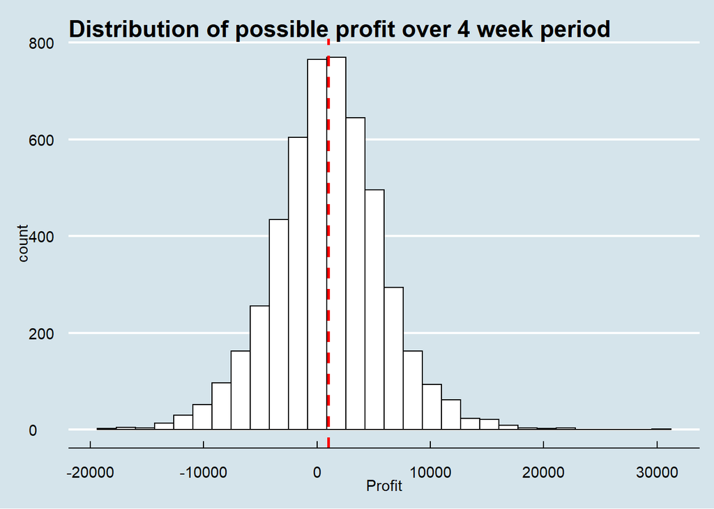

What’s our Value at Risk for this portfolio for a 4 week period with a 5% confidence?

```
##        5%
## -6970.087
```

Would you look at that, with a more diversified portfolio, we got almost half the value at risk (VaR) at 5% confidence intervals compared to the more concentrated portfolio we analyzed before.